# 08_Pipelines

## Composite Estimators using Pipeline & FeatureUnions

### Agenda

1. Introduction to Composite Estimators
2. Pipelines
3. TransformedTargetRegressor

### 1. Introduction to Composite Estimators

- One or more transformers are connected to estimators resulting into composite estimator.
- Composite transformer is implemented using Pipeline
- FeatureUnion is used to concatenate output of transformers to create derived feature
- Pipeline make machine learning code reuseable & modular

### 2. Pipeline

- Before data is fed to learning algorithm, it needs to be handled for missing values.
- Different pre-processing needs to be done.
- The output of preprocessor is to be subjected to next preprocessor & finally the estimator
- This whole process can be automated using Pipeline

[figure not shown]

- Intermediate steps .i.e transformers must implement fit & transform
- The same trained pipeline can used for prediction

#### Predicting Cancer

```python
import pandas as pd
```

```python
from sklearn.datasets import load_breast_cancer
```

```python
cancer_data = load_breast_cancer()
cancer_data
```

[output not shown]

```python
df = pd.DataFrame(cancer_data.data, columns = cancer_data.feature_names)
```

```python
df
```

|  | mean radius | mean texture | mean perimeter | mean area | mean smoothness | mean compactness | mean concavity | mean concave points | mean symmetry | mean fractal dimension | ... | worst radius | worst texture | worst perimeter | worst area | worst smoothness | worst compactness | worst concavity | worst concave points | worst symmetry | worst fractal dimension |
| --- | --- | --- | --- | --- | --- | --- | --- | --- | --- | --- | --- | --- | --- | --- | --- | --- | --- | --- | --- | --- | --- |
| 0 | 17.99 | 10.38 | 122.80 | 1001.0 | 0.11840 | 0.27760 | 0.30010 | 0.14710 | 0.2419 | 0.07871 | ... | 25.380 | 17.33 | 184.60 | 2019.0 | 0.16220 | 0.66560 | 0.7119 | 0.2654 | 0.4601 | 0.11890 |
| 1 | 20.57 | 17.77 | 132.90 | 1326.0 | 0.08474 | 0.07864 | 0.08690 | 0.07017 | 0.1812 | 0.05667 | ... | 24.990 | 23.41 | 158.80 | 1956.0 | 0.12380 | 0.18660 | 0.2416 | 0.1860 | 0.2750 | 0.08902 |
| 2 | 19.69 | 21.25 | 130.00 | 1203.0 | 0.10960 | 0.15990 | 0.19740 | 0.12790 | 0.2069 | 0.05999 | ... | 23.570 | 25.53 | 152.50 | 1709.0 | 0.14440 | 0.42450 | 0.4504 | 0.2430 | 0.3613 | 0.08758 |
| 3 | 11.42 | 20.38 | 77.58 | 386.1 | 0.14250 | 0.28390 | 0.24140 | 0.10520 | 0.2597 | 0.09744 | ... | 14.910 | 26.50 | 98.87 | 567.7 | 0.20980 | 0.86630 | 0.6869 | 0.2575 | 0.6638 | 0.17300 |
| 4 | 20.29 | 14.34 | 135.10 | 1297.0 | 0.10030 | 0.13280 | 0.19800 | 0.10430 | 0.1809 | 0.05883 | ... | 22.540 | 16.67 | 152.20 | 1575.0 | 0.13740 | 0.20500 | 0.4000 | 0.1625 | 0.2364 | 0.07678 |
| ... | ... | ... | ... | ... | ... | ... | ... | ... | ... | ... | ... | ... | ... | ... | ... | ... | ... | ... | ... | ... | ... |
| 564 | 21.56 | 22.39 | 142.00 | 1479.0 | 0.11100 | 0.11590 | 0.24390 | 0.13890 | 0.1726 | 0.05623 | ... | 25.450 | 26.40 | 166.10 | 2027.0 | 0.14100 | 0.21130 | 0.4107 | 0.2216 | 0.2060 | 0.07115 |
| 565 | 20.13 | 28.25 | 131.20 | 1261.0 | 0.09780 | 0.10340 | 0.14400 | 0.09791 | 0.1752 | 0.05533 | ... | 23.690 | 38.25 | 155.00 | 1731.0 | 0.11660 | 0.19220 | 0.3215 | 0.1628 | 0.2572 | 0.06637 |
| 566 | 16.60 | 28.08 | 108.30 | 858.1 | 0.08455 | 0.10230 | 0.09251 | 0.05302 | 0.1590 | 0.05648 | ... | 18.980 | 34.12 | 126.70 | 1124.0 | 0.11390 | 0.30940 | 0.3403 | 0.1418 | 0.2218 | 0.07820 |
| 567 | 20.60 | 29.33 | 140.10 | 1265.0 | 0.11780 | 0.27700 | 0.35140 | 0.15200 | 0.2397 | 0.07016 | ... | 25.740 | 39.42 | 184.60 | 1821.0 | 0.16500 | 0.86810 | 0.9387 | 0.2650 | 0.4087 | 0.12400 |
| 568 | 7.76 | 24.54 | 47.92 | 181.0 | 0.05263 | 0.04362 | 0.00000 | 0.00000 | 0.1587 | 0.05884 | ... | 9.456 | 30.37 | 59.16 | 268.6 | 0.08996 | 0.06444 | 0.0000 | 0.0000 | 0.2871 | 0.07039 |

569 rows × 30 columns

```python
# to do
# build a pipeline and train the models
# evaluate them
```

```python
from sklearn.pipeline import make_pipeline
```

```python
from sklearn.linear_model import LogisticRegression
from sklearn.tree import DecisionTreeClassifier
from sklearn.ensemble import RandomForestClassifier
from sklearn.svm import SVC
```

```python
from sklearn.preprocessing import RobustScaler
from sklearn.impute import SimpleImputer
```

```python
pipelines = []
for model in [LogisticRegression(max_iter=1000, solver="saga"), DecisionTreeClassifier(), RandomForestClassifier(), SVC(C=10)]:
    pipeline = make_pipeline(
              SimpleImputer(strategy="mean"),
              RobustScaler(),
              model,
              verbose=True)
    pipelines.append(pipeline)
```

```python
pipelines[1].steps[2]
```

```
('decisiontreeclassifier', DecisionTreeClassifier())
```

```python
pipelines[2].steps[2]
```

```
('randomforestclassifier', RandomForestClassifier())
```

```python
from sklearn.model_selection import train_test_split
```

```python
trainX,testX,trainY,testY = train_test_split(cancer_data.data, cancer_data.target)
```

```python
for pipeline in pipelines:
    pipeline.fit(trainX, trainY)
```

```
[Pipeline] ..... (step 1 of 3) Processing simpleimputer, total=   0.0s
[Pipeline] ...... (step 2 of 3) Processing robustscaler, total=   0.0s
[Pipeline]  (step 3 of 3) Processing logisticregression, total=   0.2s
[Pipeline] ..... (step 1 of 3) Processing simpleimputer, total=   0.0s
[Pipeline] ...... (step 2 of 3) Processing robustscaler, total=   0.0s
[Pipeline]  (step 3 of 3) Processing decisiontreeclassifier, total=   0.0s
[Pipeline] ..... (step 1 of 3) Processing simpleimputer, total=   0.0s
[Pipeline] ...... (step 2 of 3) Processing robustscaler, total=   0.0s
[Pipeline]  (step 3 of 3) Processing randomforestclassifier, total=   0.2s
[Pipeline] ..... (step 1 of 3) Processing simpleimputer, total=   0.0s
[Pipeline] ...... (step 2 of 3) Processing robustscaler, total=   0.0s
[Pipeline] ............... (step 3 of 3) Processing svc, total=   0.0s
```

```python
for pipeline in pipelines:
    print (pipeline.score(testX, testY))
```

```
0.986013986013986
0.9230769230769231
0.9440559440559441
0.972027972027972
```

```python
from sklearn.metrics import classification_report
```

```python
for pipeline in pipelines:
    print(pipeline.steps[2])
    print (classification_report(testY, pipeline.predict(testX)))
```

```
('logisticregression', LogisticRegression(max_iter=1000, solver='saga'))
              precision    recall  f1-score   support

           0       1.00      0.96      0.98        53
           1       0.98      1.00      0.99        90

    accuracy                           0.99       143
   macro avg       0.99      0.98      0.98       143
weighted avg       0.99      0.99      0.99       143

('decisiontreeclassifier', DecisionTreeClassifier())
              precision    recall  f1-score   support

           0       0.96      0.83      0.89        53
           1       0.91      0.98      0.94        90

    accuracy                           0.92       143
   macro avg       0.93      0.90      0.92       143
weighted avg       0.93      0.92      0.92       143

('randomforestclassifier', RandomForestClassifier())
              precision    recall  f1-score   support

           0       0.96      0.89      0.92        53
           1       0.94      0.98      0.96        90

    accuracy                           0.94       143
   macro avg       0.95      0.93      0.94       143
weighted avg       0.94      0.94      0.94       143

('svc', SVC(C=10))
              precision    recall  f1-score   support

           0       0.96      0.96      0.96        53
           1       0.98      0.98      0.98        90

    accuracy                           0.97       143
   macro avg       0.97      0.97      0.97       143
weighted avg       0.97      0.97      0.97       143
```

#### Caching transformers within a Pipeline

- Storing state of transformers is also possible to prevent recomputation of transformers
- When pipeline is subjected to GridSearch situations like this happens

```python
from sklearn.model_selection import GridSearchCV
```

```python
svc_pipe =  make_pipeline(
              CountVectorizer(stop_words='english'),
              TfidfTransformer(),
              SVC())
```

```python
dt_pipe = make_pipeline(
              CountVectorizer(stop_words='english'),
              TfidfTransformer(),
              DecisionTreeClassifier())
```

```python
svc_pipe
```

```
Pipeline(memory=None,
         steps=[('countvectorizer',
                 CountVectorizer(analyzer='word', binary=False,
                                 decode_error='strict',
                                 dtype=<class 'numpy.int64'>, encoding='utf-8',
                                 input='content', lowercase=True, max_df=1.0,
                                 max_features=None, min_df=1,
                                 ngram_range=(1, 1), preprocessor=None,
                                 stop_words='english', strip_accents=None,
                                 token_pattern='(?u)\\b\\w\\w+\\b',
                                 tokenizer=Non...one)),
                ('tfidftransformer',
                 TfidfTransformer(norm='l2', smooth_idf=True,
                                  sublinear_tf=False, use_idf=True)),
                ('svc',
                 SVC(C=1.0, break_ties=False, cache_size=200, class_weight=None,
                     coef0=0.0, decision_function_shape='ovr', degree=3,
                     gamma='scale', kernel='rbf', max_iter=-1,
                     probability=False, random_state=None, shrinking=True,
                     tol=0.001, verbose=False))],
         verbose=False)
```

```python
svc_pipe.steps[2]
```

```
('svc',
 SVC(C=1.0, break_ties=False, cache_size=200, class_weight=None, coef0=0.0,
     decision_function_shape='ovr', degree=3, gamma='scale', kernel='rbf',
     max_iter=-1, probability=False, random_state=None, shrinking=True,
     tol=0.001, verbose=False))
```

```python
import numpy as np
params = {
    'svc__C': list(np.logspace(1,20,20))
}
```

```python
dt_pipe.steps[2]
```

```
('decisiontreeclassifier',
 DecisionTreeClassifier(ccp_alpha=0.0, class_weight=None, criterion='gini',
                        max_depth=None, max_features=None, max_leaf_nodes=None,
                        min_impurity_decrease=0.0, min_impurity_split=None,
                        min_samples_leaf=1, min_samples_split=2,
                        min_weight_fraction_leaf=0.0, presort='deprecated',
                        random_state=None, splitter='best'))
```

```python
params = {
    'countvectorizer__max_features':[5000,7500,10000],
    'decisiontreeclassifier__max_depth':[100,200]
}
```

```python
gs = GridSearchCV(dt_pipe,cv=5,param_grid=params, n_jobs=-1)
```

```python
%timeit gs.fit(trainX,trainY)
```

[output not shown]

```python
gs.best_params_
```

[output not shown]

```python
gs.best_score_
```

[output not shown]

%timeit gs.fit(trainX,trainY)

```python
! pip install sklearn.utils
```

[output not shown]

```python
from tempfile import mkdtemp
from shutil import rmtree
from sklearn.utils import Memory

cachedir = mkdtemp()
memory = Memory(location=cachedir, verbose=0)
svc_pipe_cached =  make_pipeline(
              CountVectorizer(stop_words='english'),
              TfidfTransformer(),
              SVC(), memory = memory)
```

```python
! pip install joblib
joblib.memory
```

```python
params = {
    'svc__C': list(np.logspace(1,20,20))
}
```

```python
gs_cached = GridSearchCV(svc_pipe_cached,cv=5,param_grid=params, verbose=0)
```

```python
%timeit gs_cached.fit(trainX,trainY)
```

[output not shown]

[output cut: 65 more lines]

[output not shown]

[output not shown]

[output cut: 97 more lines]

[output not shown]

### 3. Transforming target in regression

- Dependent variables & independent variables should be linearly related
- In case, dependent variable is not normally distribted. We can make it happen for better error.
- The prediction also needs to be remapped
- This entire process can be automated using TransformedTargetRegressor

```python
from sklearn.datasets import load_boston
from sklearn.linear_model import LinearRegression
from sklearn.model_selection import train_test_split
```

```python
boston = load_boston()
```

[output not shown]

```python
boston
```

[output not shown]

[output cut: 9 more lines]

```
        12.5,  8.5,  5. ,  6.3,  5.6,  7.2, 12.1,  8.3,  8.5,  5. , 11.9,
        27.9, 17.2, 27.5, 15. , 17.2, 17.9, 16.3,  7. ,  7.2,  7.5, 10.4,
         8.8,  8.4, 16.7, 14.2, 20.8, 13.4, 11.7,  8.3, 10.2, 10.9, 11. ,
         9.5, 14.5, 14.1, 16.1, 14.3, 11.7, 13.4,  9.6,  8.7,  8.4, 12.8,
        10.5, 17.1, 18.4, 15.4, 10.8, 11.8, 14.9, 12.6, 14.1, 13. , 13.4,
        15.2, 16.1, 17.8, 14.9, 14.1, 12.7, 13.5, 14.9, 20. , 16.4, 17.7,
        19.5, 20.2, 21.4, 19.9, 19. , 19.1, 19.1, 20.1, 19.9, 19.6, 23.2,
        29.8, 13.8, 13.3, 16.7, 12. , 14.6, 21.4, 23. , 23.7, 25. , 21.8,
        20.6, 21.2, 19.1, 20.6, 15.2,  7. ,  8.1, 13.6, 20.1, 21.8, 24.5,
        23.1, 19.7, 18.3, 21.2, 17.5, 16.8, 22.4, 20.6, 23.9, 22. , 11.9]),
 'feature_names': array(['CRIM', 'ZN', 'INDUS', 'CHAS', 'NOX', 'RM', 'AGE', 'DIS', 'RAD',
        'TAX', 'PTRATIO', 'B', 'LSTAT'], dtype='<U7'),
 'DESCR': ".. _boston_dataset:\n\nBoston house prices dataset\n---------------------------\n\n**Data Set Characteristics:**  \n\n    :Number of Instances: 506 \n\n    :Number of Attributes: 13 numeric/categorical predictive. Median Value (attribute 14) is usually the target.\n\n    :Attribute Inform…
 'filename': 'boston_house_prices.csv',
 'data_module': 'sklearn.datasets.data'}
```

```python
X = boston.data
```

```python
y = boston.target
```

```python
regressor = LinearRegression()
```

```python
X_train, X_test, y_train, y_test = train_test_split(X, y, random_state=0)
```

```python
regressor.fit(X_train, y_train)
```

```
LinearRegression()
```

```python
print('R2 score: {0:.2f}'.format(regressor.score(X_test, y_test)))
```

```
R2 score: 0.64
```

```python
pred = regressor.predict(X_test)
```

```python
from sklearn.metrics import mean_absolute_error, r2_score
```

```python
mean_absolute_error(y_pred=pred, y_true=y_test)
```

```
3.6683301481357256
```

```python
r2_score(y_pred=pred,y_true=y_test )
```

```
0.635463843320211
```

```
array([[<matplotlib.axes._subplots.AxesSubplot object at 0x7f225cfe27d0>,
      dtype=object)
```

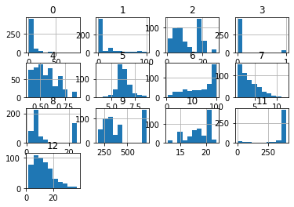

```python
import matplotlib.pyplot as plt
import pandas as pd

boston_df = pd.DataFrame(boston.data)
boston_df.hist()
```

### Convert data from non-normal distribution to normal distribution

```python
from sklearn.preprocessing import QuantileTransformer, PowerTransformer
```

```python
# pt = PowerTransformer()
```

```python
qt = QuantileTransformer(n_quantiles=500, output_distribution='normal')
```

```python
#X_tf = pt.fit_transform(X)
#OR
X_tf = qt.fit_transform(X)
```

```
array([[<matplotlib.axes._subplots.AxesSubplot object at 0x7f225c4b0fd0>,
      dtype=object)
```

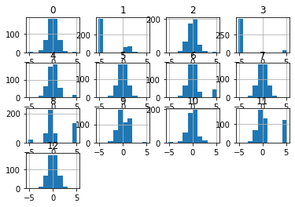

```python
boston_df_transformed = pd.DataFrame(X_tf)
boston_df_transformed.hist()
```

```python
X_train, X_test, y_train, y_test = train_test_split(X_tf, y, random_state=0)
```

```python
regressor = LinearRegression()
```

```python
regressor.fit(X_train, y_train)
```

```
LinearRegression()
```

```python
print('R2 score: {0:.2f}'.format(regressor.score(X_test, y_test)))
```

```
R2 score: 0.66
```

```python
pred = regressor.predict(X_test)
```

```python
mean_absolute_error(y_pred=pred, y_true=y_test)
```

```
3.6336016920720833
```

```python
from sklearn.compose import TransformedTargetRegressor
```

```python
regr = TransformedTargetRegressor(regressor=regressor,transformer=qt)
```

```python
regr.fit(X_train, y_train)
```

```
TransformedTargetRegressor(regressor=LinearRegression(),
                           transformer=QuantileTransformer(n_quantiles=500,
                                                           output_distribution='normal'))
```

```python
pred = regr.predict(X_test)
```

```python
mean_absolute_error(y_pred=pred, y_true=y_test)
```

```
3.3488150694668417
```

```python
r2_score(y_pred=pred, y_true=y_test)
```

```
0.7103483397791333
```

#### Hyper-parameters of TransformedTargetRegressor

- regressor - initialized model
- transformer - which supports transform & inverse_transform functions
- function - to convert target
- inverse_function - to convert back predicted target in original data scale